# Reproducible Research: Peer Assessment 1

## Loading and preprocessing the data

```r
activity <- read.csv("activity.csv")
completeActivity <- activity[complete.cases(activity),]
```

## What is mean total number of steps taken per day?

Compute total number of steps taken per day

```r
totalStepsPerDay <- aggregate(completeActivity$steps, by=list(date=completeActivity$date), FUN=sum)
```

Create the histogram for total number of steps per day

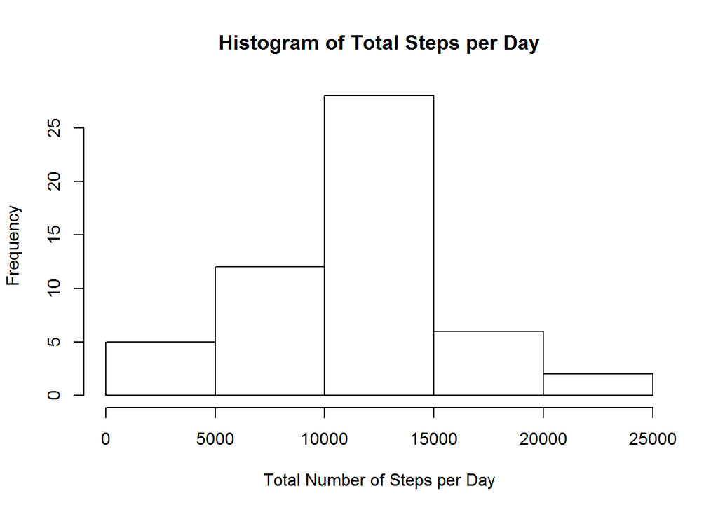

```r
hist(totalStepsPerDay$x, main="Histogram of Total Steps per Day", xlab="Total Number of Steps per Day")
```

```r
meanStepsPerDay <- mean(completeActivity$steps)
medianStepsPerDay <- median(completeActivity$steps)
```

## What is the average daily activity pattern?

Compute the average number of steps per interval

```r
totalStepsPerInterval <- aggregate(completeActivity$steps, by=list(interval=completeActivity$interval), FUN=sum)
library(plyr)
averageStepsPerInterval <- mutate(totalStepsPerInterval, x = x / nrow(totalStepsPerDay))
```

Create the time-series plot of the 5-minute inteval and the average number of steps taken, averaged across all days

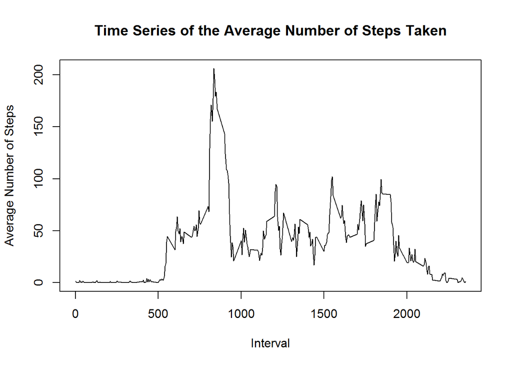

```r
plot(x ~ interval, averageStepsPerInterval, type="l", xlab="Interval", ylab="Average Number of Steps", main="Time Series of the Average Number of Steps Taken")
```

Find the 5-minute interval that contains the maximum number of steps on average across all the days in the dataset

```r
maxStepsPerInterval <- averageStepsPerInterval[averageStepsPerInterval$x == max(averageStepsPerInterval$x),]
```

The interval that contains the maximum number of steps is 835

## Imputing missing values

Calcuate the total number of missing values in the dataset

```r
totalNumberMissingValues <- nrow(activity) - nrow(completeActivity)
```

The total number of missing values in the dataset is 2304

Impute missing values by using the average for the 5-minute interval

```r
imputedCompleteActivity <- activity
for(i in 1:nrow(imputedCompleteActivity)) {
  if (is.na(imputedCompleteActivity[i,]$steps)) {
    imputedCompleteActivity[i,]$steps <- averageStepsPerInterval[averageStepsPerInterval$interval == imputedCompleteActivity[i,]$interval,]$x
  }
}
```

Compute total number of steps taken per day using dataset with missing data filled in

```r
totalStepsPerDayFilledIn <- aggregate(imputedCompleteActivity$steps, by=list(date=imputedCompleteActivity$date), FUN=sum)
```

Create the histogram for total number of steps per day

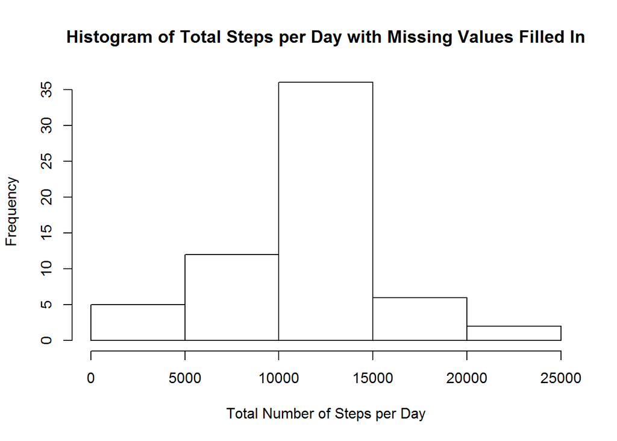

```r
hist(totalStepsPerDayFilledIn$x, main="Histogram of Total Steps per Day with Missing Values Filled In", xlab="Total Number of Steps per Day")
```

```r
meanStepsPerDayFilledIn <- mean(imputedCompleteActivity$steps)
medianStepsPerDayFilledIn <- median(imputedCompleteActivity$steps)
```

## Are there differences in activity patterns between weekdays and weekends?

Create a new factor indicating whether it is in weekdays or weekend

```r
imputedCompleteActivity <- mutate(imputedCompleteActivity, weekend = ifelse(weekdays(as.Date(imputedCompleteActivity$date)) %in% c("Saturday","Sunday"),"weekend", "weekdays"))
imputedCompleteActivity <- mutate(imputedCompleteActivity, weekend = as.factor(weekend))
```

Partition the dataset into two parts: weekdays and weekend

```r
imputedCompleteActivityWeekend <- imputedCompleteActivity[imputedCompleteActivity$weekend=="weekend",]
imputedCompleteActivityWeekdays <- imputedCompleteActivity[imputedCompleteActivity$weekend=="weekdays",]
```

Compute total numbers of steps per interval for weekend and weekdays

```r
totalStepsPerIntervalFilledInWeekdays <- aggregate(imputedCompleteActivityWeekdays$steps, by=list(interval=imputedCompleteActivityWeekdays$interval), FUN=sum)
averageStepsPerIntervalWeekdays <- mutate(totalStepsPerIntervalFilledInWeekdays, x = x / nrow(imputedCompleteActivityWeekdays))
totalStepsPerIntervalFilledInWeekend <- aggregate(imputedCompleteActivityWeekend$steps, by=list(interval=imputedCompleteActivityWeekend$interval), FUN=sum)
averageStepsPerIntervalWeekend <- mutate(totalStepsPerIntervalFilledInWeekend, x = x / nrow(imputedCompleteActivityWeekend))
```

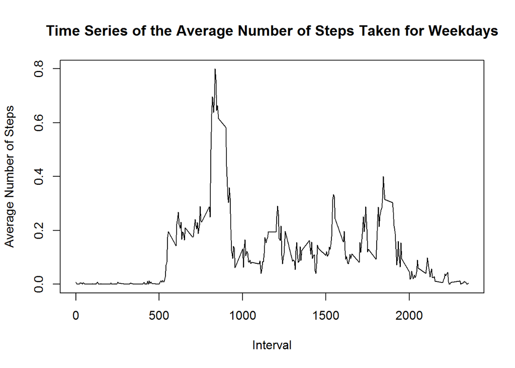

```r
plot(x ~ interval, averageStepsPerIntervalWeekdays, type="l", xlab="Interval", ylab="Average Number of Steps", main="Time Series of the Average Number of Steps Taken for Weekdays")
```

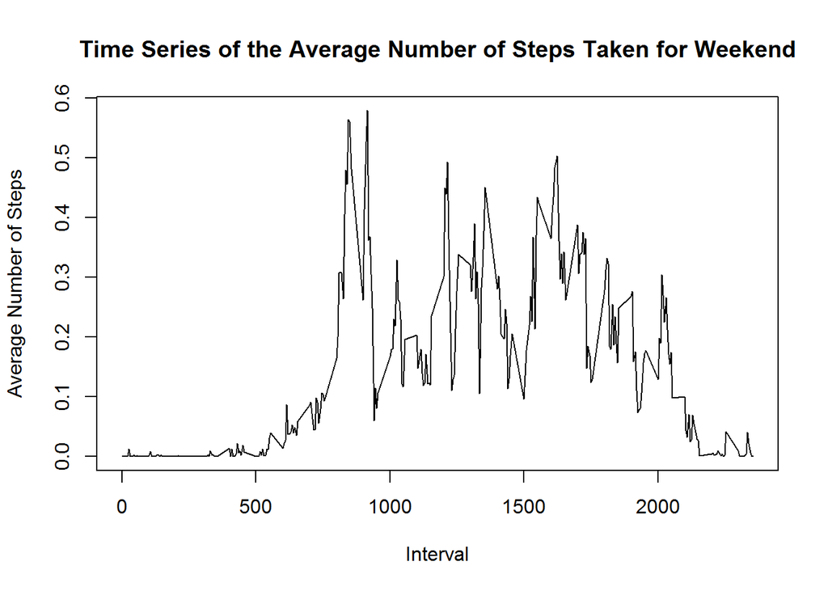

```r
plot(x ~ interval, averageStepsPerIntervalWeekend, type="l", xlab="Interval", ylab="Average Number of Steps", main="Time Series of the Average Number of Steps Taken for Weekend")
```